# Second_plot

Marcelladane

26 July 2017

**Instructions**

*Fine particulate matter (PM2.5) is an ambient air pollutant for which there is strong evidence that it is harmful to human health. In the United States, the Environmental Protection Agency (EPA) is tasked with setting national ambient air quality standards for fine PM and for tracking the emissions of this pollutant into the atmosphere. Approximatly every 3 years, the EPA releases its database on emissions of PM2.5. This database is known as the National Emissions Inventory (NEI). You can read more information about the NEI at the EPA National Emissions Inventory web site.*

For each year and for each type of PM source, the NEI records how many tons of PM2.5 were emitted from that source over the course of the entire year. The data that you will use for this assignment are for 1999, 2002, 2005, and 2008.

**PM2.5 Emissions Data structure**

The files contain the follow columns *fips*: A five-digit number (represented as a string) indicating the U.S. county *SCC*: The name of the source as indicated by a digit string (see source code classification table) *Pollutant*: A string indicating the pollutant *Emissions*: Amount of PM2.5 emitted, in tons *type*: The type of source (point, non-point, on-road, or non-road) *year*: The year of emissions recorded

**Question**

2 - Have total emissions from PM2.5 decreased in the Baltimore City, Maryland (fips == “24510”) from 1999 to 2008? Use the base plotting system to make a plot answering this question.

First you shall loaded some packages I might need to use Second, downloaded the data set (I called exdata) and saved on my working directory and then read 2 different tables for the SSC and NEI; SSC = Source Classification Code NEI = National Emissions Inventory

```r
packages <- c("data.table", "reshape2")
sapply(packages, require, character.only = TRUE, quietly = TRUE)
```

```
## data.table   reshape2
##       TRUE       TRUE
```

```r
unzip("exdata.zip")

NEI <- readRDS("summarySCC_PM25.rds")
SCC <- readRDS("Source_Classification_Code.rds")
```

Now you can create a table that is a subset (just Baltimore) of the data in NEI. Since the request was for total emission per year. Use *tapply* to create a new table. This table will have the *sum* by year for Baltimore.

```r
sub_balt <- subset(NEI, fips == "24510")
head(sub_balt)
```

```
##         fips      SCC Pollutant Emissions  type year
## 114288 24510 10100601  PM25-PRI     6.532 POINT 1999
## 114296 24510 10200601  PM25-PRI    78.880 POINT 1999
## 114300 24510 10200602  PM25-PRI     0.920 POINT 1999
## 114308 24510 30100699  PM25-PRI    10.376 POINT 1999
## 114325 24510 30183001  PM25-PRI    10.859 POINT 1999
## 114329 24510 30201599  PM25-PRI    83.025 POINT 1999
```

```r
sum_balt <- tapply(sub_balt$Emissions, sub_balt$year, sum)
head(sum_balt)
```

```
##     1999     2002     2005     2008
## 3274.180 2453.916 3091.354 1862.282
```

Finally plot the output. No specs of the type of graphic we were suppose to make I made a basic plot with magenta dots to show the valeus of sum and connected them using type=“o” Also added labels for the plot

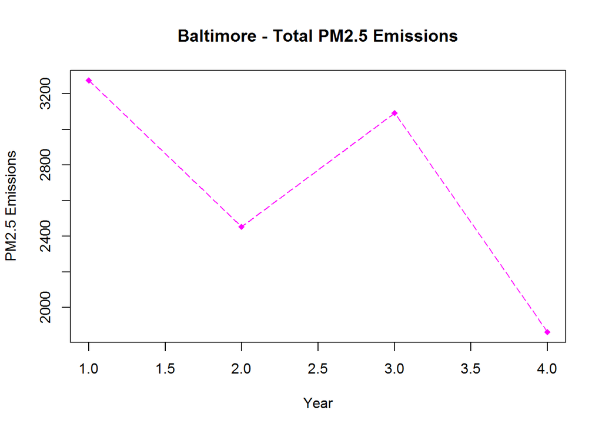

```r
plot(sum_balt, main = "Baltimore - Total PM2.5 Emissions", xlab = "Year", ylab = "PM2.5 Emissions", pch = 18, col = "magenta", lty = 5, type = "o")
```